# AI Exercises for Kids Count Data Center (Solutions)

# AI Exercise Session Plan

We will work through 2 interactive exercises using AI tools. If your organization has an approved tool, feel free to use that. Otherwise, a free version of ChatGPT, Gemini, or the like will work great for illustrative purposes. As a disclaimer, these examples were aided themselves by AI tools!

This toy example deals with American Community Survey data on child poverty and showcases the usefulness of AI for catching mistakes, cleaning up messy code, and doing some preliminary data visualization.

# Exercise 1 - Documentation and Debugging

## Objective

We will start with an R function that is messy and has a bug in it. With assistance, we will clean up the code, add documentation, and fix the bug.

## Instructions

1. Review the R code snippet below. Run it in your R environment to see what it does at baseline.
2. There are two bugs in the current function. Draft a prompt to ask your AI tool to rewrite the function to fix the bugs. You can try without telling it the bugs at first to check what it identifies, and then provide hints if needed.
   1. All of the margin-of-error variables (ending in ‘_M’) are included by default in `tidycensus`. Without logic keeping only the estimates (ending in ‘_E’) in the numerator, our calculations will be off base.
   2. the denominator is the wrong universe - it is currently set to everyone, but it should only be the <18 population.
3. The function is poorly documented. Ask AI to add function docstrings to explain what the function does, its inputs, and its outputs, as well as any clarifying in-line comments that might be necessary to explain assumptions
4. Review the refined function. Test to ensure it works as expected and note any key differences.

```r
library(tidyverse)
library(tidycensus)

# 1. Read in the toy dataset
county_child_pov_ar <- read_csv('toy-data/child-poverty-ar.csv')
# 2. Code to get the right list of variables in our numerator and in our denominator
year <- 2023
survey <- "acs5"
vars <- load_variables(year, survey, cache = TRUE)


under18_ages <- "(Under 5 years|5 years|6 to 11 years|12 to 14 years|15 years|16 and 17 years)"

num_vars <- vars %>%
  filter(str_detect(name, "^B17001_"),
           str_detect(label,
                      paste0("Estimate!!Total:!!Income in the past 12 months below poverty level:!!(Male|Female):!!",
                             under18_ages))) %>%
  pull(name)

# NOTE: den_vars calculation moved to SOLUTION section to keep the example intentionally buggy


# 2. Existing function to compute child poverty percentage by Arkansas census tract
calculate_child_pov_pct <- function(d) {
  d %>%
    transmute(
      GEOID, NAME,
      num = rowSums(across(matches(paste0("^(\\", paste(num_vars, collapse="|"), ")")))), # grab all numerator columns
      den = B17001_001E # Grab total count for the B17_001 table as denominator
    ) %>%
    mutate(child_poverty_rate_pct = 100 * num / den) %>%
    arrange(desc(child_poverty_rate_pct))
}

calculate_child_pov_pct(county_child_pov_ar)
```

```
# A tibble: 823 × 5
   GEOID       NAME                             num   den child_poverty_rate_pct
   <chr>       <chr>                          <dbl> <dbl>                  <dbl>
 1 05119980100 Census Tract 9801; Pulaski Co…   143     0                  Inf
 2 05069000102 Census Tract 1.02; Jefferson …   143    41                  349.
 3 05119980200 Census Tract 9802; Pulaski Co…   143    45                  318.
 4 05091980000 Census Tract 9800; Miller Cou…   143   113                  127.
 5 05119004104 Census Tract 41.04; Pulaski C…  1994  3157                   63.2
 6 05143010404 Census Tract 104.04; Washingt…  1668  2768                   60.3
 7 05119980400 Census Tract 9804; Pulaski Co…   320   574                   55.7
 8 05069001401 Census Tract 14.01; Jefferson…   809  1739                   46.5
 9 05119002800 Census Tract 28; Pulaski Coun…   843  1820                   46.3
10 05035030702 Census Tract 307.02; Crittend…   436  1008                   43.3
# ℹ 813 more rows
```

### SOLUTION (reference)

The full solution and sample prompts live in this notebook. The corrected function below (minimal, with comments) fixes the two issues: it sums only estimate columns (excludes _M) and uses the under‑18 estimate columns as the denominator. A short sample AI prompt is provided after the code.

```r
# Prepare denominator variable list
den_vars <- vars %>%
  filter(str_detect(name, "^B17001_"),
         str_detect(label,
                    paste0("Estimate!!Total:!!(Income in the past 12 months (below|at or above) poverty level):!!(Male|Female):!!",
                           under18_ages))) %>%
    pull(name)

# Solution: corrected, minimal function
#' Calculate child poverty percent (under-18)
#' d: data.frame with ACS wide columns like B17001_XXXE
#' num_codes, den_codes: vectors of B17001 codes (no E/M suffix)
calculate_child_pov_pct_solution <- function(d, num_codes, den_codes) {
  num_cols <- paste0(num_codes, "E")
  den_cols <- paste0(den_codes, "E")

  num_present <- intersect(num_cols, names(d))
  den_present <- intersect(den_cols, names(d))

  d %>%
    transmute(
      GEOID, NAME,
      num = if (length(num_present) > 0) rowSums(across(all_of(num_present)), na.rm = TRUE) else 0,
      den = if (length(den_present) > 0) rowSums(across(all_of(den_present)), na.rm = TRUE) else 0
    ) %>%
    mutate(child_poverty_rate_pct = if_else(den > 0, 100 * num / den, NA_real_))
}

# Run the solution on the toy data
child_pov_pct_solution <- calculate_child_pov_pct_solution(county_child_pov_ar, num_vars, den_vars)
child_pov_pct_solution %>% slice_max(child_poverty_rate_pct, n = 6)
```

```
# A tibble: 6 × 5
  GEOID       NAME                              num   den child_poverty_rate_pct
  <chr>       <chr>                           <dbl> <dbl>                  <dbl>
1 05093010100 Census Tract 101; Mississippi …   330   350                   94.3
2 05119980400 Census Tract 9804; Pulaski Cou…   107   116                   92.2
3 05041950300 Census Tract 9503; Desha Count…   185   219                   84.5
4 05027950500 Census Tract 9505; Columbia Co…   864  1029                   84.0
5 05107480500 Census Tract 4805; Phillips Co…   369   447                   82.6
6 05119002800 Census Tract 28; Pulaski Count…   518   632                   82.0
```

Sample AI prompt (pasteable):”

“Fix the function: use estimate (E) columns only; use <18 population as denominator; handle divide-by-zero; add docstring.”

# Exercise 2 - Data Visualization

## Objective

We will ask AI to assist with creating data visualization and iteratively make improvements until we have what we want.

## Instructions:

1. We will use the cleaned data from Exercise 1. If you did not complete that, you can read in this updated dataset:

```r
child_poverty_ar_pct <- read_csv('toy-data/child-poverty-ar-pct.csv')
```

2. Ask your AI tool to create a heat map of child poverty rates statewide using `ggplot2.`
3. Ask your AI tool to improve chart readability for use in a slide deck. What might we consider asking for? A prompting tip: Providing context like why you are asking this question, specific changes you want to see, the desired format of your output, and who the target audience is can all be helpful.
4. Ask your tool to generate a caption and short blurb to explain the narrative throughline of the chart for a non-technical audience. Can we evaluate what it generates together?———————————————————————

### SOLUTION (reference)

Below is a compact, slide-ready mapping solution. It uses a colorblind-safe palette and a county-level fallback for speed. The code saves a PNG suitable for slides.

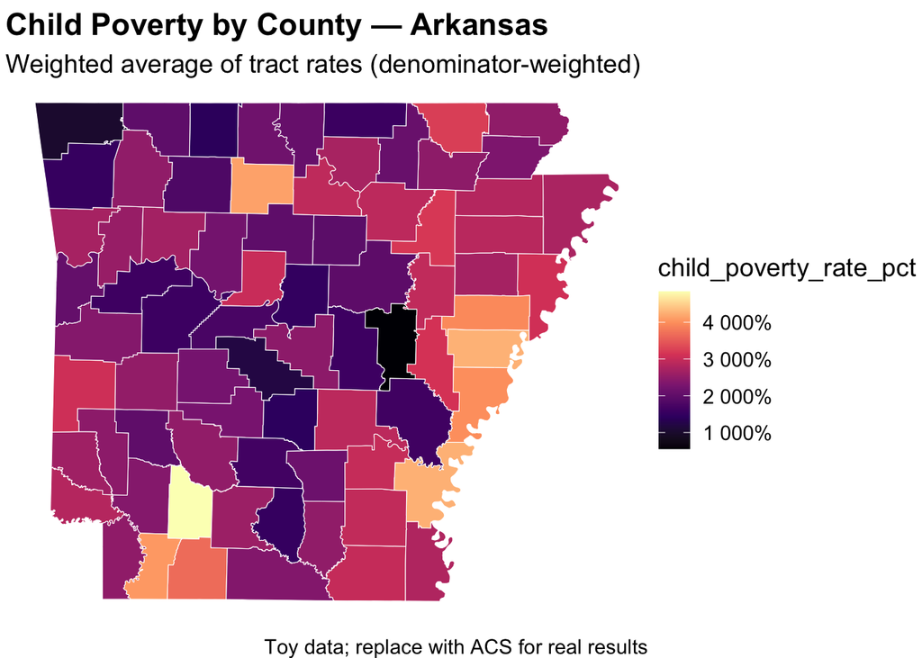

```r
library(tidyverse)
library(tigris)
library(sf)
library(viridis)
library(scales)
options(tigris_use_cache = TRUE)

# Get Arkansas tract geometries
ar_tracts <- tracts(state = "AR", year = 2023, cb = TRUE)

# Join the cleaned poverty data from Exercise 1 solution
poverty_map_data <- ar_tracts %>%
  left_join(child_pov_pct_solution %>% select(GEOID, child_poverty_rate_pct, den), by = "GEOID")

# County-level aggregation (fast and slide-friendly)
county_map_data <- poverty_map_data %>%
  mutate(county_geoid = substr(GEOID, 1, 5)) %>%
  group_by(county_geoid) %>%
  summarize(child_poverty_rate_pct = weighted.mean(child_poverty_rate_pct, w = den, na.rm = TRUE), geometry = st_union(geometry), .groups = "drop")

p_county_solution <- ggplot(county_map_data) +
  geom_sf(aes(fill = child_poverty_rate_pct), color = "white", size = 0.2) +
  scale_fill_viridis_c(option = "magma", na.value = "grey90", labels = percent_format(accuracy = 1)) +
  labs(title = "Child Poverty by County — Arkansas", subtitle = "Weighted average of tract rates (denominator-weighted)", caption = "Toy data; replace with ACS for real results") +
  theme_void(base_size = 14) + theme(legend.position = "right", plot.title = element_text(face = "bold"))

# Save slide-ready image
ggsave("toy-data/child_poverty_county_slide_solution.png", p_county_solution, width = 10, height = 7, dpi = 300)

# Print preview
p_county_solution
```

Suggested prompt for visualization refinement (pasteable):

“Write R code to generate from this dataset a slide-ready county map of child poverty rates and save a PNG.”